# Network models and structural analysis

**Blas Kolic, 2025**

In this tutorial, we take a deeper dive into networks by exploring several of their structural properties. We begin with one of the most common and powerful tools in network analysis: centrality measures. Then, we learn how to draw informative network visualizations using `networkx`, breaking down the key elements involved: placing nodes, drawing edges, adding labels, and coloring nodes according to network features. Then, we will extract significant clusters using community detection methods and assess the quality of the detected communities. Finally, we generate random networks using different network models and use them as a null benchmark to test whether features of real networks can be explained by randomness.

We will work with the **2025 Conclave social network**, a dataset capturing relationships between cardinals. This network was constructed and analyzed by a group of scholars at Bocconi University. Their analysis—conducted after Pope Francis passed away but **before** the new Pope was elected—found that Cardinal Prevost was the most central figure in terms of status. In network terms, he had the highest *eigenvector centrality*: he was important because he was connected to other important nodes. You can find the original press article [here](https://www.unibocconi.it/en/news/network-conclave) and the GitHub repository with raw data [here](https://github.com/leonardorizzo/Conclave2025). A cleaned and processed version of the network is included at `session_2/data/conclave/edgelist_conclave_final.csv`, which we will analyze in this tutorial.

**Structure of the tutorial**

1. **Reading**: Load and process the Conclave social network
2. **Centrality**: Measure which nodes are most important in the network
3. **Network visualization**: Create a visualization highlighting key nodes and features
4. **Community detection**: Identify communities the from network structure and compute modularity
5. **Network models**: Generate random networks and compare them to the empirical network
6. **Optional exercises**: Practice your coding and network analysis skills

**PS: Installing an extra Python package**

For this tutorial, we need the `scikit-learn` package (used for ML tools and standardized evaluation metrics). You can install it by:

1. opening a command shell (Anaconda Prompt on Windows; Terminal on macOS),
2. activating the workshop environment with `conda activate networks_workshop`, and
3. installing the package using `pip install scikit-learn`.

```python
# Import libraries
import networkx as nx
import pandas as pd
import numpy as np
import matplotlib.pyplot as plt
from sklearn.metrics import normalized_mutual_info_score
```

## Reading the Conclave social network

In this network, a node is a cardinal in the College of Cardinals, i.e., a potential candidate for being the new pope, and edges are multilayered: edges in the first layer represent the *episcopal consecration* between cardinals (i.e., which cardinals where ordained by whom), while an edge in the second layer represents the number of *co-memberships* between cardinals (i.e., on how many institutions the cardinals work together).

The network we will analyze below combines these layers into a single layer that aggregates the weight of the edges at each layer. For the construction of this network, see the original [Conclave Github repository](https://github.com/leonardorizzo/Conclave2025) and the `conclave_network_construction.ipynb` notebook included in the `session_2/extras` folder.

```python
# Create network
## Read edgelist representing the Conclave network
edgelist = pd.read_csv('data/conclave/edgelist_conclave_final.csv')
print(edgelist.head(10))

## Create networkx (undirected) graph from edgelist
G = nx.from_pandas_edgelist(edgelist, edge_attr='weight', create_using=nx.Graph)
```

```
         source    target  weight
0  Aguiar Alves  Clemente       1
1  Aguiar Alves  Gambetti       1
2  Aguiar Alves        Bo       1
3  Aguiar Alves  Langlois       1
4  Aguiar Alves  Semeraro       1
5  Aguiar Alves     Maeda       1
6      Clemente  Mendonça       1
7      Clemente   Nichols       1
8      Clemente   Scherer       1
9      Clemente   Ouellet       1
```

```python
# Each node can have features. Let's add them
## Read node features
node_features = pd.read_csv('data/conclave/node_info.csv', index_col=0)
## Add node features to the network
feature_dict = node_features.to_dict(orient="index")
nx.set_node_attributes(G, feature_dict)

## print a couple of node features
print("Features of some of the nodes:")
for D in list(G.nodes(data=True))[:10]:
    print(f' - {D[0]}: {D[1]}')
```

```
Features of some of the nodes:
 - Aguiar Alves: {'Age': 51.3, 'Nationality_Category': 'Europe (no Italy)', 'Lean': 'Liberal'}
 - Clemente: {'Age': 76.7, 'Nationality_Category': 'Europe (no Italy)', 'Lean': 'Soft Conservative'}
 - Gambetti: {'Age': 59.5, 'Nationality_Category': 'Italy', 'Lean': 'Soft Liberal'}
 - Bo: {'Age': 76.4, 'Nationality_Category': 'Asia e Oceania', 'Lean': 'Soft Conservative'}
 - Langlois: {'Age': 66.4, 'Nationality_Category': 'Africa', 'Lean': 'Moderate'}
 - Semeraro: {'Age': 77.3, 'Nationality_Category': 'Italy', 'Lean': 'Soft Liberal'}
 - Maeda: {'Age': 76.1, 'Nationality_Category': 'Asia e Oceania', 'Lean': 'Moderate'}
 - Mendonça: {'Age': 59.3, 'Nationality_Category': 'Europe (no Italy)', 'Lean': 'Soft Liberal'}
 - Nichols: {'Age': 79.4, 'Nationality_Category': 'Italy', 'Lean': 'Soft Conservative'}
 - Scherer: {'Age': 75.6, 'Nationality_Category': 'South America', 'Lean': 'Soft Conservative'}
```

## Centrality analysis

The original authors focused on two main centrality metrics:

- **Eigenvector centrality**: They call it *Status*. Measures how important a node is based on the importance of its neighbors. A node is central if it is connected to other central nodes.
- **Betweenness centrality**: They call it *Information Control*. Measures how often a node lies on the shortest paths between others. A node is central if it acts as a bridge connecting different parts of the network.

*Most centrality measures are already included in `networkx` (with shorthand `nx`). Explore more centrality metrics by yourself!*

```python
# Compute Status index (eigenvector centrality)
centrality_eigen = nx.eigenvector_centrality(G)
## sort centrality by decreasing order (the higher, the more central)
centrality_eigen = sorted(centrality_eigen.items(), key=lambda x: x[1], reverse=True)
## print top centralities
print("Top nodes by Status (eigenvector centrality):")
for node, centrality in centrality_eigen[:10]:
    print(f" - {node}: {centrality:.4f}")
```

```
Top nodes by Status (eigenvector centrality):
 - Prevost: 0.1664
 - Tagle: 0.1591
 - Parolin: 0.1559
 - Gugerotti: 0.1558
 - Fernández: 0.1550
 - Mendonça: 0.1527
 - You Heung-Sik: 0.1522
 - Roche: 0.1445
 - Sarah: 0.1431
 - Sturla Berhouet: 0.1395
```

```python
# Compute Information Control index (betweenness centrality)
centrality_betw = nx.betweenness_centrality(G)
## sort centrality by decreasing order (the higher, the more central)
centrality_betw = sorted(centrality_betw.items(), key=lambda x: x[1], reverse=True)
## print top centralities
print("Top nodes by Information Control (betweenness centrality):")
for node, centrality in centrality_betw[:10]:
    print(f" - {node}: {centrality:.4f}")
```

```
Top nodes by Information Control (betweenness centrality):
 - Re: 0.0573
 - Bertone: 0.0541
 - Tagle: 0.0437
 - Prevost: 0.0381
 - Betori: 0.0335
 - Fernández: 0.0313
 - Romeo: 0.0309
 - Tobin: 0.0304
 - Parolin: 0.0299
 - Zuppi: 0.0298
```

Finally, let's see if these centralities are correlated or not. Do "Information Control" and "Status" give us the same information or not? Let's find out.

```
             Status  Information Control
Prevost    0.166367             0.038078
Tagle      0.159147             0.043723
Parolin    0.155938             0.029908
Gugerotti  0.155838             0.023212
Fernández  0.154963             0.031280
```

|  | Status | Information Control |
| --- | --- | --- |
| Status | 1.00 | 0.45 |
| Information Control | 0.45 | 1.00 |

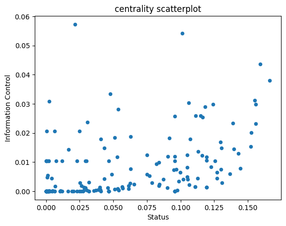

```python
## First create a table of centralities
df_centralities = pd.DataFrame(
    [dict(centrality_eigen), dict(centrality_betw)],
    index=['Status', 'Information Control']
).T # T stands for transpose: changes rows for columns
print(df_centralities.head())

## Create a scatterplot between centrality measures
df_centralities.plot(kind='scatter', x='Status', y='Information Control', title='centrality scatterplot')

## Compute correlation
df_centralities.corr().round(2)
```

The correlation is positive, although not super high, so they both give complementary information.

## Network Visualization

The simplest way to visualize a network in NetworkX is:

```
  nx.draw(G)
```

This works, but the result is usually messy or hard to read. To create clearer and more informative visualizations, we will follow a simple sequence of steps that give us more control over the layout and appearance of the plot.

**Steps for Creating a Clear Network Visualization**

1. **Compute node positions**  
   Use a layout (usually the spring layout `nx.spring_layout`) to decide where nodes should be placed. Connected nodes naturally appear closer together.
2. **Draw the edges**  
   Plot edges first so they stay in the background and don't cover the nodes. See `nx.draw_networkx_edges`.
3. **Draw the nodes (size by degree)**  
   Plot the nodes, scaling their size by degree so highly connected nodes appear larger and more prominent. See `nx.draw_networkx_nodes`.
4. **Add node labels (size by degree)**  
   Label mostly the more connected nodes and scale label size by degree to keep the plot readable. See `nx.draw_networkx_labels`.
5. **Color nodes by an attribute**  
   Assign colors to nodes based on a meaningful attribute (e.g., community, role), helping highlight patterns in the network. Colors can be passed as a list into `nx.draw_networkx_nodes`.

Following this sequence (**positions → edges → nodes → labels → colors**) produces clean, informative visualizations that reveal both structure and content.

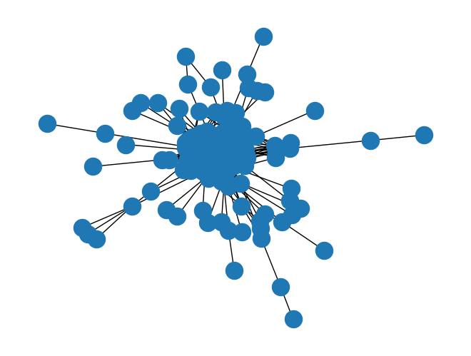

```python
# First, visualize the network simply with nx.draw

## TIP: Visualize the largest connected component so we don't visualize disconnected islands
largest_cc_nodes = max(nx.connected_components(G), key=len)
G_largest = G.subgraph(largest_cc_nodes).copy()

## Plot
nx.draw(G_largest)
```

This looks all cluttered. Let's improve it by creating a *visualization helper function* with the steps above.

```python
# Network visualization function: step by step!
## 1. node positions
## 2. draw edges
## 3. draw nodes (size according to degree)
## 4. draw node labels (size according to degree)
def draw_network(
        G,                         # the network
        pos = None,                # node positions
        node_colors = "#5b8cc0", # this can be a list (element i is the color of node i)
        show_labels = True,        # should node labels be displayed?
        figsize = 10,               # size of the frame
):
    "Draws a network with nodes and node labels scaled by their degree"

    ## Some visualizatoin parameters first
    node_min_size = 5
    node_size_scaling = 10
    node_label_scaling = 1
    degree_sequence = dict(G.degree)
    average_degree = np.mean( list(degree_sequence.values()) )

    ## Compute node positions (if you don't pass it externally as an argument)
    if pos is None:
        pos = nx.spring_layout(G)

    ## Calculate node and label sizes by degree (make hubs bigger)
    degrees = dict(G.degree())
    mean_degree = np.mean( list( degrees.values()) )
    label_sizes, node_sizes = dict(), []
    for node, degree in degree_sequence.items():
        # Set node size
        size = node_min_size + node_size_scaling * degree # scales linearly with degree
        node_sizes.append(size)
        # Set label size
        if degree >= average_degree:
            label_size = node_label_scaling * np.sqrt(degree) # scales with square root of degree
            label_sizes[node] = label_size
        else:
            label_sizes[node] = 0

    # Draw network
    plt.figure(figsize=(figsize, figsize))
    ## First, draw edges
    nx.draw_networkx_edges(
        G, pos,
        alpha=0.05, # alpha controls transparency
    )
    ## Then, draw nodes
    nx.draw_networkx_nodes(
        G, pos,
        node_size=node_sizes,
        node_color=node_colors,
        linewidths=1,
        edgecolors="white",
    )
    ## Finally, draw node labels
    if show_labels:
        nx.draw_networkx_labels(
            G, pos,
            font_size=label_sizes,
        )
    return plt.axis("off")
```

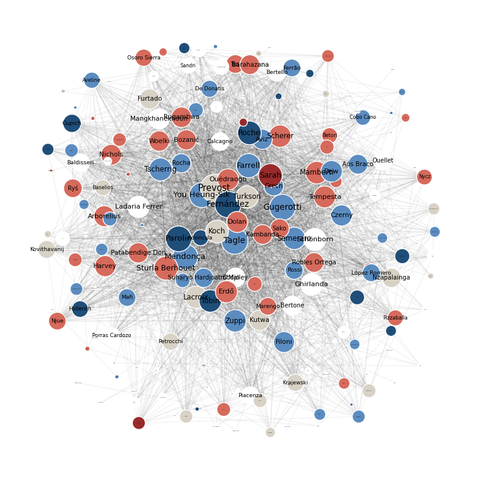

```python
## TIP: Visualize the largest connected component so we don't visualize disconnected islands
largest_cc_nodes = max(nx.connected_components(G), key=len)
G_largest = G.subgraph(largest_cc_nodes).copy()

## Calculate nodes position (spring layout: the more connected the nodes, the closer)
## Note: higher k (try between 0 and 1) spreads the nodes apart
pos = nx.spring_layout(
    G_largest,
    k=0.75,
    iterations=10,
    weight='weight',
    seed=0
)

## Set node colors according to node features (cardinal ideologu, in this case)
palette = {
    "Liberal":           "#1f4e79",  # dark blue
    "Soft Liberal":      "#5b8cc0",  # medium blue
    "Moderate":          "#d8d1c5",  # beige / light taupe
    "Soft Conservative": "#d66a5c",  # soft red / coral
    "Conservative":      "#992b2b",  # deep red
    "Non-voting":        "#ffffff"   # white
}
node_colors = [palette[ideology] for _, ideology in G_largest.nodes(data='Lean')]

## Visualize the network using our helper function
draw_network(
    G = G_largest,
    pos = pos,
    node_colors = node_colors,
);
```

## Community Detection

Beyond coloring nodes by ideology, we can also uncover **data-driven communities** based purely on the network structure. We use the **Louvain method** to find clusters that maximize **modularity**, a measure of how well the network splits into tightly connected groups. We will do this with `nx.community.louvain_communities`.

After detecting communities, we convert them into a `{node: community}` format, assign each community a color, and redraw the network.

We can then compare:

- the **ideology partition**, and
- the **Louvain community partition**

by computing their **modularity** and checking how well they align using **Normalized Mutual Information (NMI)** (0 = unrelated, 1 = identical).

```python
# helper functions
## Note: these will help change between the format needed to color nodes and the one given when detecting communities
def partition_to_setlist(partition):
    """Transforms a partition (node: feature) into a dictionary (feature: set of nodes with feature).
    This is useful for doing community-based things in networkx
    """
    unique_features = set( partition.values() )
    setlist = dict()
    for feature in unique_features:
        feature_setlist = {node for node, feat in partition.items() if feat == feature}
        setlist[feature] = feature_setlist
    return setlist

def setlist_to_partition(setlist):
    """Transforms a setlist (feature: set of nodes with feature) into a partition (node : feature).
    """
    if type(setlist) == list:
        return {node: feat for feat, nodes in enumerate(setlist) for node in nodes}
    if type(setlist) == dict:
        return {node: feat for feat, nodes in setlist.items() for node in nodes}
```

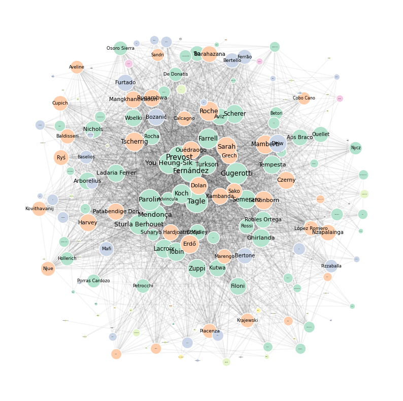

```python
# Redraw the network but coloring the nodes according to detected communities.

## 1. Detect communities using Louvain's method
communities = nx.community.louvain_communities(G_largest)
## 2. Use our helper function to format communities into {node:community} dictionary
communities_dict = setlist_to_partition(communities)
## 3. Choose some colors (different from previous) and assign a color to each node
from matplotlib import colormaps
pallete_comm = colormaps['Pastel2'].resampled(len(communities))
node_colors_comm = [pallete_comm(community) for _, community in communities_dict.items()]

## Redraw network with detected communities
draw_network(
    G = G_largest,
    pos = pos, # same as in the cell above,
    node_colors=node_colors_comm
);
```

```python
# Calculate modularity of:
## 1. Cardinal ideologies
## 2. Detected communities

## Format ideologies into using helper function (list of sets of nodes)
ideologies = dict( G_largest.nodes(data='Lean') )
ideologies_setlist = partition_to_setlist(ideologies).values()
## Compute modularity
Q_ideologies  = nx.community.modularity(G_largest, ideologies_setlist)
Q_communities = nx.community.modularity(G_largest, communities)

print(f"Modularity of ideology partition: {round(Q_ideologies, 3)}")
print(f"Modularity of community detection: {round(Q_communities, 3)}")
```

```
Modularity of ideology partition: -0.001
Modularity of community detection: 0.217
```

```python
# Are ideologies similar to detected communities?
## Normalized Mutual Information (NMI) (0 = unrelated; 1 = equal )
from sklearn.metrics import normalized_mutual_info_score

## Transform from dict to list
comms = list(communities_dict.values())
ideos = list(ideologies.values())
## Compute NMI score
nmi = normalized_mutual_info_score(comms, ideos)
print("Normalized mutual information:", round(nmi, 2))
```

```
Normalized mutual information: 0.11
```

## Network Models

To understand whether the structure of our empirical network can be explained by simple generative processes, we compare it to several classic **random network models**. Each model captures a different mechanism of tie formation:

- **Erdős–Rényi model** — every pair of nodes connects with probability *p* (pure randomness). See `nx.erdos_renyi_graph`
- **Configuration model** — preserves the exact degree sequence but randomizes everything else. See `nx.configuration_model`
- **Watts–Strogatz model** — starts regular, then randomly rewires edges to create small-world structure. See `nx.watts_strogatz_graph`
- **Regular network model** — each node has the same degree and no randomness. We'll use `nx.watts_strogatz_graph`

We will sample networks from each model, compute basic statistics (e.g., assortativity, clustering, modularity, diameter), and compare them to the empirical network. We will also compare centrality measures and test whether the *configuration model* can statistically reproduce key metrics such as *assortativity* and *transitivity*, helping us understand which structural features can and cannot be explained by simple randomness.

```python
# Generate random networks using basic properties of the empirical network.

## Empirical network properties
degree_sequence = [ k for node,k in G.degree ]
degree_avg = np.mean(degree_sequence)
N = G.number_of_nodes()
p = degree_avg / N # prob. of sampling random edge
p_rewiring = 0.1

## Sample random networks from each model
G_er   = nx.erdos_renyi_graph(N, p=p, create_using=nx.Graph)
G_conf = nx.configuration_model(degree_sequence, create_using=nx.Graph)
G_ws   = nx.watts_strogatz_graph(N, k=int(degree_avg), p = p_rewiring, create_using=nx.Graph)
G_reg  = nx.watts_strogatz_graph(N, k=int(degree_avg), p = 0, create_using=nx.Graph)

## Assign original node names
index2name = {i:name for i,name in enumerate(G.nodes)}
G_er   = nx.relabel_nodes(G_er, index2name)
G_conf = nx.relabel_nodes(G_conf, index2name)
G_ws   = nx.relabel_nodes(G_ws, index2name)
G_reg  = nx.relabel_nodes(G_reg, index2name)
```

With these random networks, we can compute basic network descriptors.

```python
## Helper to compute basic statistics of a network
def network_statistics(G):
    "Compute basic stats for a given network G."
    # Network overall size
    N = G.number_of_nodes()
    L = G.number_of_edges()
    k_avg = 2*L / N # we saw this formula in class

    # Largest connected component (LCC)
    components = list(nx.connected_components(G))
    largest_component = max(components, key=len)
    G_lcc = G.subgraph(largest_component)

    # Modularity (community detection)
    communities = nx.community.louvain_communities(G)
    n_comms = len(communities)
    Q = nx.community.modularity(G, communities)

    # Compile statistics into a dictionary
    stats = {
        "nodes": N,
        "edges": L,
        "avg_degree": k_avg,
        "density": nx.density(G),
        "transitivity": nx.transitivity(G),
        "assortativity": nx.degree_assortativity_coefficient(G),
        "modularity (optimal)": Q,
        "n_communities": n_comms,
        "LCC_size": len(largest_component)/N,
        "LCC_diameter": nx.diameter(G_lcc)
    }
    return stats

## Create a dictionary of the empirical and generated networks
networks = {
    'empirical': G,
    'erdos_renyi': G_er,
    'configuration': G_conf,
    'watts_strogatz': G_ws,
    'regular': G_reg,
}

## Compute network statistics and create a table
stats = [network_statistics(network) for network in networks.values()]
stats_table = pd.DataFrame( stats, index=networks.keys() )
stats_table.round(2)
```

|  | nodes | edges | avg_degree | density | transitivity | assortativity | modularity (optimal) | n_communities | LCC_size | LCC_diameter |
| --- | --- | --- | --- | --- | --- | --- | --- | --- | --- | --- |
| empirical | 190 | 2886 | 30.38 | 0.16 | 0.62 | 0.02 | 0.22 | 12 | 0.98 | 8 |
| erdos_renyi | 190 | 2878 | 30.29 | 0.16 | 0.16 | -0.04 | 0.14 | 8 | 1.00 | 3 |
| configuration | 190 | 2314 | 24.36 | 0.13 | 0.34 | -0.04 | 0.13 | 7 | 1.00 | 5 |
| watts_strogatz | 190 | 2850 | 30.00 | 0.16 | 0.53 | 0.01 | 0.51 | 5 | 1.00 | 3 |
| regular | 190 | 2850 | 30.00 | 0.16 | 0.72 | NaN | 0.57 | 4 | 1.00 | 7 |

We can also check the centrality measures on each random network and compare them against the empirical

```python
## eigenvector centrality revisited (Status)
centralities_eigen = [nx.eigenvector_centrality(g) for g in networks.values()]
# Create a DataFrame table to check correlations
df_centrality_eigen = pd.DataFrame(
    centralities_eigen,
    index=networks.keys(),
).T

print("Correlation table:")
df_centrality_eigen.corr().round(3)
```

```
Correlation table:
```

|  | empirical | erdos_renyi | configuration | watts_strogatz | regular |
| --- | --- | --- | --- | --- | --- |
| empirical | 1.000 | 0.083 | 0.979 | -0.290 | NaN |
| erdos_renyi | 0.083 | 1.000 | 0.090 | -0.021 | NaN |
| configuration | 0.979 | 0.090 | 1.000 | -0.277 | NaN |
| watts_strogatz | -0.290 | -0.021 | -0.277 | 1.000 | NaN |
| regular | NaN | NaN | NaN | NaN | NaN |

```python
## betweenness centrality revisited (Information Control)
centralities_betweenness = [nx.betweenness_centrality(g) for g in networks.values()]
# Create a DataFrame table to check correlations
df_centrality_betweenness = pd.DataFrame(
    centralities_betweenness,
    index=networks.keys(),
).T

print("Correlation table:")
df_centrality_betweenness.corr().round(3)
```

```
Correlation table:
```

|  | empirical | erdos_renyi | configuration | watts_strogatz | regular |
| --- | --- | --- | --- | --- | --- |
| empirical | 1.000 | 0.058 | 0.373 | 0.086 | -0.013 |
| erdos_renyi | 0.058 | 1.000 | 0.040 | -0.006 | -0.069 |
| configuration | 0.373 | 0.040 | 1.000 | 0.094 | -0.037 |
| watts_strogatz | 0.086 | -0.006 | 0.094 | 1.000 | -0.000 |
| regular | -0.013 | -0.069 | -0.037 | -0.000 | 1.000 |

What happens if we plot the actual centrality scores for each of the networks?

- What similarities do they have with the empirical network?
- What can you observe happens with the centrality rankings in random networks?
- Is there any type of random network that closely matches the empirical one?

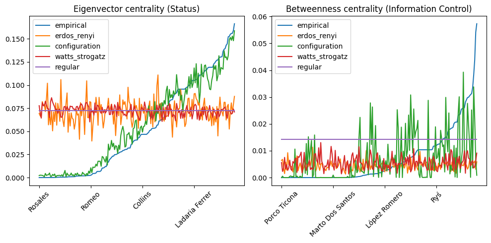

```python
# Plot centrality rankings for different networks
fig, ax = plt.subplots(ncols=2, figsize=(10,5))

df_centrality_eigen.sort_values('empirical').plot(ax=ax[0], title='Eigenvector centrality (Status)')
df_centrality_betweenness.sort_values('empirical').plot(ax=ax[1], title='Betweenness centrality (Information Control)')
# present x-ticks in a cleaner way
ax[0].tick_params(axis='x', rotation=45)
ax[1].tick_params(axis='x', rotation=45)

## Makes plot tighter for better presentation
plt.tight_layout()
```

We often use random networks as **null models** to test whether a feature of the empirical network (e.g., clustering or assortativity) could simply be the result of chance. The idea is straightforward: we generate many random networks, measure the same feature on each one, and look at the **distribution** of those values. Then we check where the empirical value falls.

- If it lies **inside** the distribution, the random model can explain the feature.
- If it lies **outside**, the empirical network shows structure that the random model cannot reproduce.

This gives us a simple, intuitive statistical test: compare the real network to an ensemble of randomized versions and see whether its features are “expected” or “surprising” under that model.

Below, we test whether the configuration model (rewiring edges at random but fixing degree sequence) can explain the *assortativity coefficient* and *clustering coefficient* of the empirical Conclave network.

```
Z-score (assortativity): 3.88 (>2 -> significant)
Z-score (transitivity): 66.72 (>2 -> significant)
```

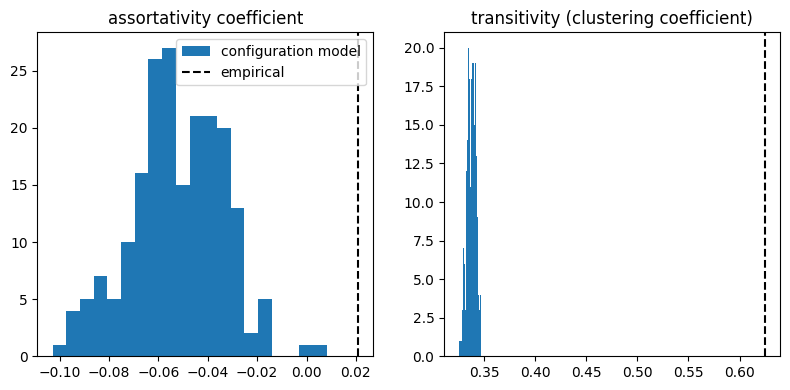

```python
# First, create an ensemble of random networks using the *configuration model*
## Note: each network will be different because edges are placed at random (for a given degree sequence)
n_networks = 200
degree_sequence = [ k for node,k in G_largest.degree ]
ensemble_conf = [nx.configuration_model(degree_sequence, create_using=nx.Graph) for _ in range(n_networks)]

# Let's compare some empirical features to the distribution of the null ensemble
## 1. assortativity
assortativity_null = [nx.degree_assortativity_coefficient(g) for g in ensemble_conf]
assortativity_empirical  = nx.degree_assortativity_coefficient(G)
## 2. transitivity (clustering coefficient)
transitivity_null = [nx.transitivity(g) for g in ensemble_conf]
transitivity_empirical  = nx.transitivity(G)

# Visualize results
fig, ax = plt.subplots(ncols=2, figsize=(8,4))
## assortativity
ax[0].hist(assortativity_null, label='configuration model', bins=20)
ax[0].axvline(assortativity_empirical, color='black', linestyle='--', label='empirical')
ax[0].set_title('assortativity coefficient')
ax[0].legend()
## transitivity
ax[1].hist(transitivity_null, label='configuration model', bins=20)
ax[1].axvline(transitivity_empirical, color='black', linestyle='--', label='empirical')
ax[1].set_title('transitivity (clustering coefficient)')
plt.tight_layout()

# Z-tests for significance
## Z-test: (mean_empirical - mean_null)/(std_null)
zscore_assort = (assortativity_empirical - np.mean(assortativity_null))/np.std(assortativity_null)
zscore_transit = (transitivity_empirical - np.mean(transitivity_null))/np.std(transitivity_null)
print(f"Z-score (assortativity): {zscore_assort:.2f} (>2 -> significant)")
print(f"Z-score (transitivity): {zscore_transit:.2f} (>2 -> significant)")
```

## Exercises (optional)

#### 1. Recreating the analysis with a new network

1. Choose, download, and load an **undirected network** from the [Netzschleuder Free Network Repository](https://networks.skewed.de/) that has between $N=30$ and $N=300$ nodes. To do so:
   1. Click the network name which will take you to the network description page
   2. In the `csv` column of the *Networks* table, click the box with the size of the file (e.g., `10 KiB`) and a zip with the edgelist will be downloaded.
   3. Unzip the file, and put the folder in a convenient place (e.g., in a folder called `data` alongside this Notebook)
   4. Read the edgelist in pandas with

   `edgelist = pd.read_csv('path/to/edges.csv')`
   5. Process column names (this format comes with some clutter in the header column names) with

   `edgelist.columns = [s.replace("#", "").strip() for s in edgelist.columns]`
   6. Create a `networkx` network doing

   `G = nx.from_pandas_edgelist(edgelist, create_using=nx.Graph) # for undirected, set nx.DiGraph instead`
2. Compute the eigenvector, betweenness, and degree centrality of the network. Are these measures correlated? Who are the top 5 nodes according to degree?
3. Does the network exhibit community structure? What can you find using community detection? What is the modularity of the detected partition?
4. Is the empirical degree assortativity coefficient statistically significant when compared to the configuration model? What about the transitivity (clustering coefficient)
5. Plot the network. Tweak the parameters of the `draw_network` helper function we defined above until it looks nice.

#### 2. Constructing the Conclave network by adding layers

The edgelist I provided (`edgelist_conclave_final.csv`) is an aggregate network of the Conclave. In reality, the network is formed by two main layers:

- First layer: *episcopal consecrations* between cardinals (i.e., which cardinals where ordained by whom)
- Second layer: number of *co-memberships* between cardinals (i.e., on how many institutions the cardinals work together)

In the `session_2/data/conclave/raw` folder, you will find the raw files `adjacency_matrix_consecrator.csv` and `formal.csv` representing, respecitvely, the consecration relations in an adjacency matrix format (first layer), and the insitutional memberships of each of the cardinals in the Conclave (this a bipartite network of Cardinal-Membership). Your goal is to create the Conclave network aggregating the two layers. To do so, you need to:

1. Create the consecrator network (see the `nx.from_pandas_adjacency` function)
2. Load the Cardinal-Membership table (`formal.csv`) and create a co-membership network between cardinals (i.e., an edge $i,j$ represents the number of institutions where cardinals $i$ and $j$ work together).
3. Once you have the two layers (consecrator and co-membership), aggregate the layers into a single one; if the edge exists in both layers, add their weights, if not, just add the weight of the existing layer.
4. Compare your resulting network with the one I gave you (`edgelist_conclave_final.csv`). They should be the same.

The solution to exercise 2 is at the notebook at `session_2/extras/conclave_network_construction.ipynb`.